# Data Analysis Project

Dhirendra Khanka

19-June-2019

# INTRODUCTION

This is a simple attempt in creating a Linear Regression Model to predict Temperature based on some explainatory Variables. Consider the following dataset.  
Daily readings of the following air quality values for May 1, 1973 (a Tuesday) to September 30, 1973.  
Ozone: Mean ozone in parts per billion from 1300 to 1500 hours at Roosevelt Island  
Solar.R: Solar radiation in Langleys in the frequency band 4000–7700 Angstroms from 0800 to 1200 hours at Central Park  
Wind: Average wind speed in miles per hour at 0700 and 1000 hours at LaGuardia Airport  
Temp: Maximum daily temperature in degrees Fahrenheit at La Guardia Airport.

Rows with missing data are omitted from dataset.

|  | Ozone | Solar.R | Wind | Temp | Month | Day |
| --- | --- | --- | --- | --- | --- | --- |
| 1 | 41 | 190 | 7.4 | 67 | 5 | 1 |
| 2 | 36 | 118 | 8.0 | 72 | 5 | 2 |
| 3 | 12 | 149 | 12.6 | 74 | 5 | 3 |
| 4 | 18 | 313 | 11.5 | 62 | 5 | 4 |
| 5 | NA | NA | 14.3 | 56 | 5 | 5 |
| 6 | 28 | NA | 14.9 | 66 | 5 | 6 |

Lets check to fit a linear model for tempature as predictor and Ozone, Solar and Wind as explainatory variables  
### Omit Missing Records

|  | Ozone | Solar.R | Wind | Temp | Month | Day |
| --- | --- | --- | --- | --- | --- | --- |
| 1 | 41 | 190 | 7.4 | 67 | 5 | 1 |
| 2 | 36 | 118 | 8.0 | 72 | 5 | 2 |
| 3 | 12 | 149 | 12.6 | 74 | 5 | 3 |
| 4 | 18 | 313 | 11.5 | 62 | 5 | 4 |
| 7 | 23 | 299 | 8.6 | 65 | 5 | 7 |
| 8 | 19 | 99 | 13.8 | 59 | 5 | 8 |

### Data Plots of Explainatory Variables vs Predictor Variable

Plot of Ozone level vs Temparature. - Looks like positive correlation between the two.

Plot of Wind vs Temparture - There seems to be a somewhat negative correlation between Temparature and Wind.

Plot of Solar Radiation vs Temperature - There does not seem to be much co-relation between Solar Radiation and Temparture. The points are well scattered. We will include it for now and later compare it with another model wherein Solar Radiation is not included using the DIC.

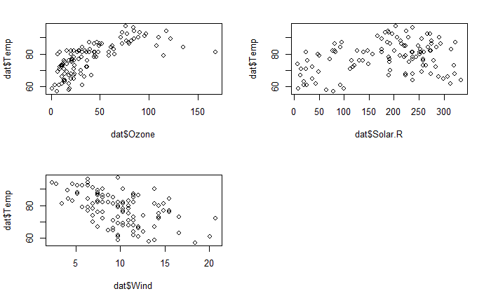

## JAGS MODEL 1

Lets build below Linear Model considering following explanatory variables affecting temparture.  
Temperature ~ Ozone + Solar.R + Wind

Consider following JAGS model

temp ~iid N(mu, sig)  
mu = Beta1 + Beta2 * Ozone + Beta3 * Solar.R + Beta4 * Wind  
beta ~ N(0, 1e6)  
sig ~ IG(1, 5)

### Summary of Model1

```r
summary(mod_sim)
```

```
Iterations = 1001:6000
Thinning interval = 1
Number of chains = 3
Sample size per chain = 5000

1. Empirical mean and standard deviation for each variable,
   plus standard error of the mean:

          Mean       SD  Naive SE Time-series SE
b[1] 72.298818 3.140545 0.0256424      0.1579479
b[2]  0.172734 0.026150 0.0002135      0.0008944
b[3]  0.007432 0.007581 0.0000619      0.0001771
b[4] -0.318057 0.228082 0.0018623      0.0105824
sig   6.762298 0.453196 0.0037003      0.0039332

2. Quantiles for each variable:

          2.5%       25%       50%      75%    97.5%
b[1] 66.180146 70.157016 72.285294 74.41117 78.49793
b[2]  0.120883  0.155238  0.173102  0.19063  0.22261
b[3] -0.007262  0.002342  0.007328  0.01243  0.02267
b[4] -0.764624 -0.475252 -0.313194 -0.16055  0.11583
sig   5.952586  6.443580  6.734016  7.05671  7.73369
```

```r
coefficients(mod)
```

```
$b
[1] 67.82260750  0.18242130  0.01903651 -0.09176961

$prec
[1] 0.01861798
```

From summary, we find that the co-efficient for Solar Radiation is close to Zero.

### DIC of Model1

Deviance Information Criterion

[output not shown]

## JAGS Model 2

Lets now build 2nd Model with following

temp ~iid N(mu, sig)  
mu = Beta1 + Beta2 * Ozone + Beta3* Wind  
beta ~ N(1, 1e6)  
sig ~ IG(1, 5)

### Convergence Diagnostic Plots

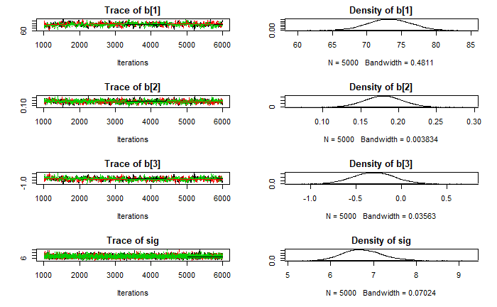

```r
plot(mod2_sim)
```

### Gelman Diag

```r
gelman.diag(mod2_sim)
```

```
Potential scale reduction factors:

     Point est. Upper C.I.
b[1]       1.01       1.04
b[2]       1.01       1.02
b[3]       1.01       1.04
sig        1.00       1.00

Multivariate psrf

1.01
```

### Summary of Model2

```r
summary(mod2_sim)
```

```
Iterations = 1001:6000
Thinning interval = 1
Number of chains = 3
Sample size per chain = 5000

1. Empirical mean and standard deviation for each variable,
   plus standard error of the mean:

        Mean      SD Naive SE Time-series SE
b[1] 73.1890 3.11847 0.025462      0.1560789
b[2]  0.1803 0.02486 0.000203      0.0009663
b[3] -0.3009 0.23015 0.001879      0.0107004
sig   6.7514 0.45608 0.003724      0.0040404

2. Quantiles for each variable:

        2.5%     25%     50%     75%   97.5%
b[1] 66.9457 71.1412 73.1932 75.3024 79.1597
b[2]  0.1322  0.1635  0.1801  0.1967  0.2296
b[3] -0.7421 -0.4567 -0.3020 -0.1485  0.1557
sig   5.9300  6.4345  6.7243  7.0421  7.7203
```

### DIC of model2

```r
dic.samples(mod2, n.iter = 1e3)
```

[output not shown]

### Residual and Q-Q Plot

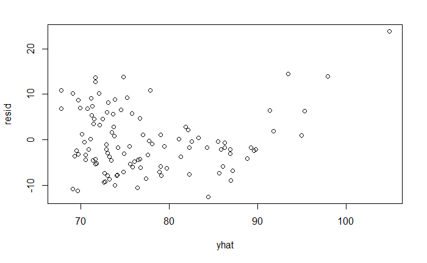

```r
coeff = coefficients(mod2)
yhat = coeff$b[1] + coeff$b[2]* data2_jags$ozone + coeff$b[3]* data2_jags$wind
resid = yhat - data2_jags$y
plot(yhat, resid)
```

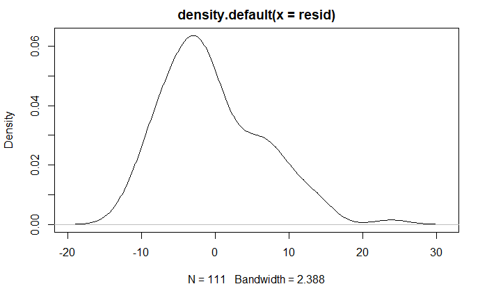

```r
plot(density(resid))
```

The QQ plot also looks okay except for 1 far off point.

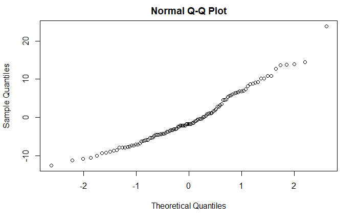

```r
qqnorm(resid)
```

```r
mod3_string = "model{
  for (i in 1: length(y)){
    y[i] ~ dnorm(mu[i], prec)
    mu[i] = b[1] + b[2]* ozone[i] + b[3]* wind[i] + b[4]* ozone[i]* ozone[i] + b[5]* wind[i]* wind[i] + b[6]* ozone[i]* wind[i]
  }

  for( j in 1:6){
    b[j] ~ dnorm(0.0, 1.0/1.0e6)
  }
  prec ~ dgamma(5/2,25)
  sig2 = 1/prec
  sig  = sqrt(sig2)
}"

data3_jags = list(y= dat$Temp, ozone = dat$Ozone, wind = dat$Wind)
mod3 = jags.model(textConnection(mod3_string),data = data3_jags, n.chains = 3)
update(mod3, n.iter = 1e3)
```

[output not shown]